# Final_Presentation

Edward Thomas

12/6/2020

Set Up:

```r
library(pracma)
library(tidyr)
library(stats)
library(ggplot2)

brt <- read.csv('data/BirthRate.csv')
drt <- read.csv('data/DeathRate.csv')
lxp <- read.csv('data/LifeExp.csv')
popgr <- read.csv('data/PopulationGrowth.csv')
totpop <- read.csv('data/TotalPopulation.csv')

foodData <- read.csv('data/FAO.csv')

list_of_dataFrames <- list(brt, drt, lxp, popgr, totpop)
```

# ———— Final ————

## Question

It’s predicted that by the year 2050 we will have 10 billion people on the planet Earth. Can we feed 10 billion people? We will analyze this question by predicting food production data based on population growth and by time and see if they correlate with an answer of the amount of food the world will need to produce to feed all 10 billion people.

## Synopsis

The idea behind this final presentation is a fear that I’ve had since I got into college and took one of my first courses, Biology, and about 2 months into the course, we were discussing the herbivore, carnivore, and omnivore section. The teacher brought up the fact that eating green is important and that if every human ate green then the earth would be able to hold 100 times more humans than it currently could. This interested me because it’s easy to say, but where do the numbers back it up? This discussion eventually let into a real-world issue biologists, scientists, and population experts say will absolutely become an problematic which is, if people continue to live the way we do, by 2050 something will have to change and this will be caused by over-population for a world that can no longer feed the people that live on it. The class abruptly switched topics, but I have forever been stuck on it, because I find it mind-boggling that no one, politicians, activists, NASA(for God sake) would think to say, “Hey, this is a problem that needs to be addressed now”. I was hoping this presentation would put me at ease, and get me an A.

## World Population

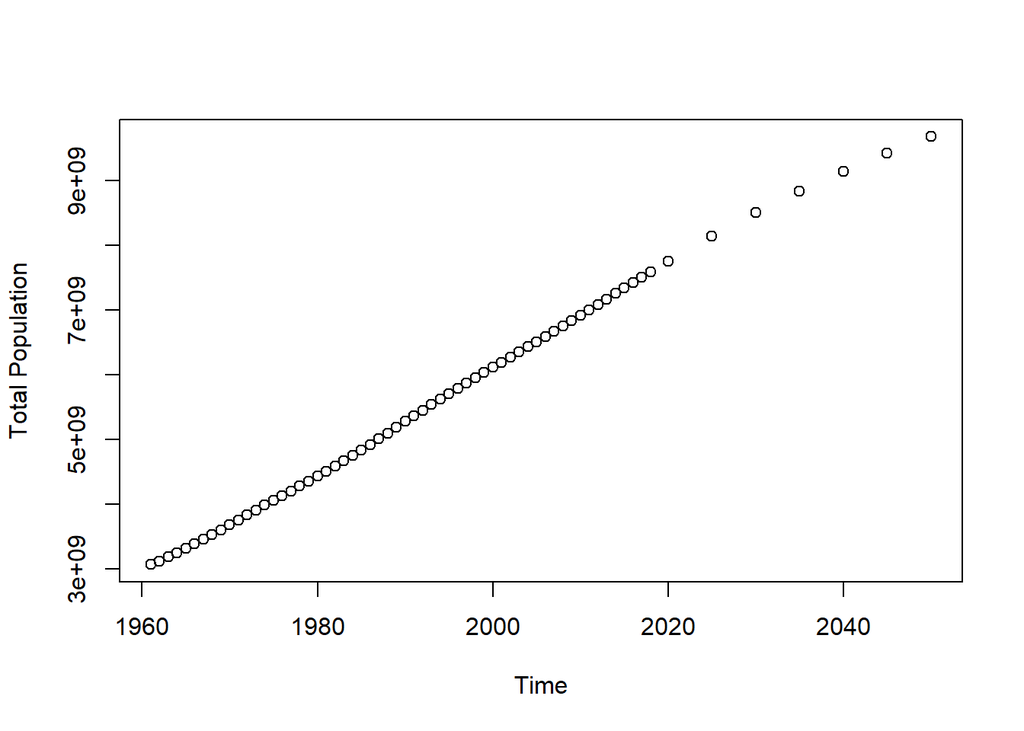

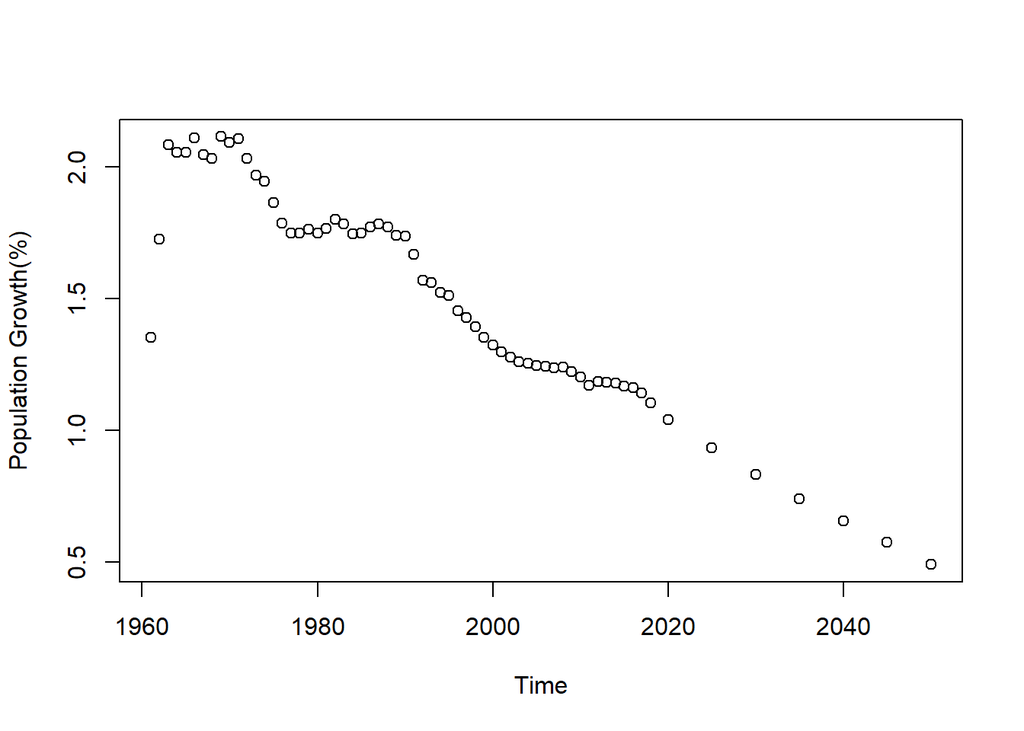

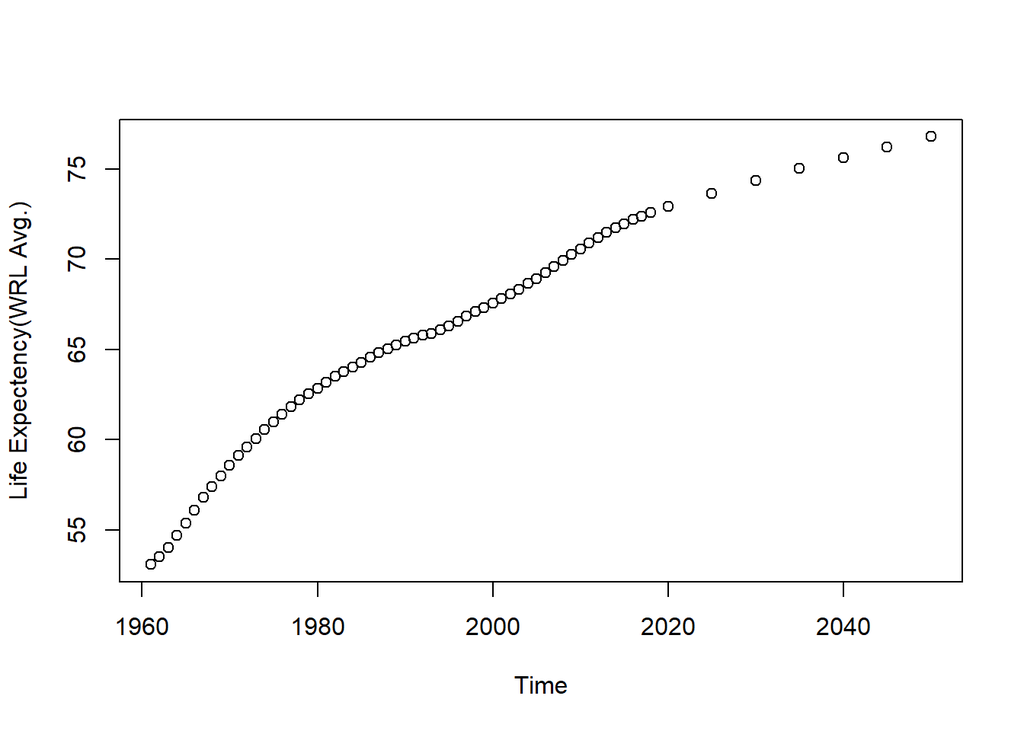

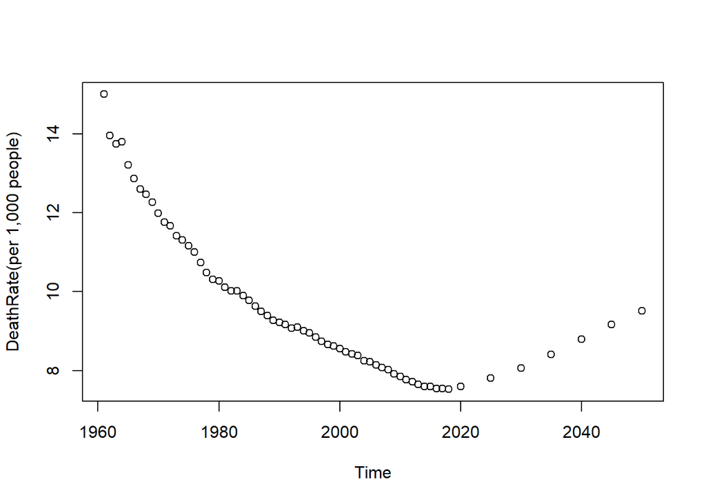

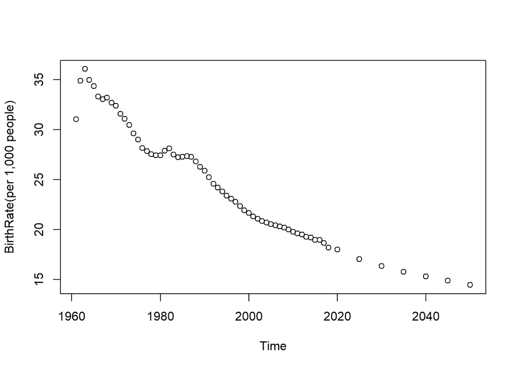

Through the research needed to get this data, along with just the casual reading of others work in similar data-explorations, I’ve come to find that most people use population data, not correspondingly with food, but with comparison to other countries or other information such as BirthRate, DeathRate, exc. This didn’t come at a huge shock, but I found people are not concerned with the topic I have found,. I have plotted above the data in respect to time, just to give a broad analysis.

### Analysis

The complete data was broken into 5 main features that were then cumulatively compiled to represent WORLD data. This was done in python, which will be submitted as well, but to get the `config.py` file to work correctly, you’ll have to look through the file and change some things around.

## Food Production

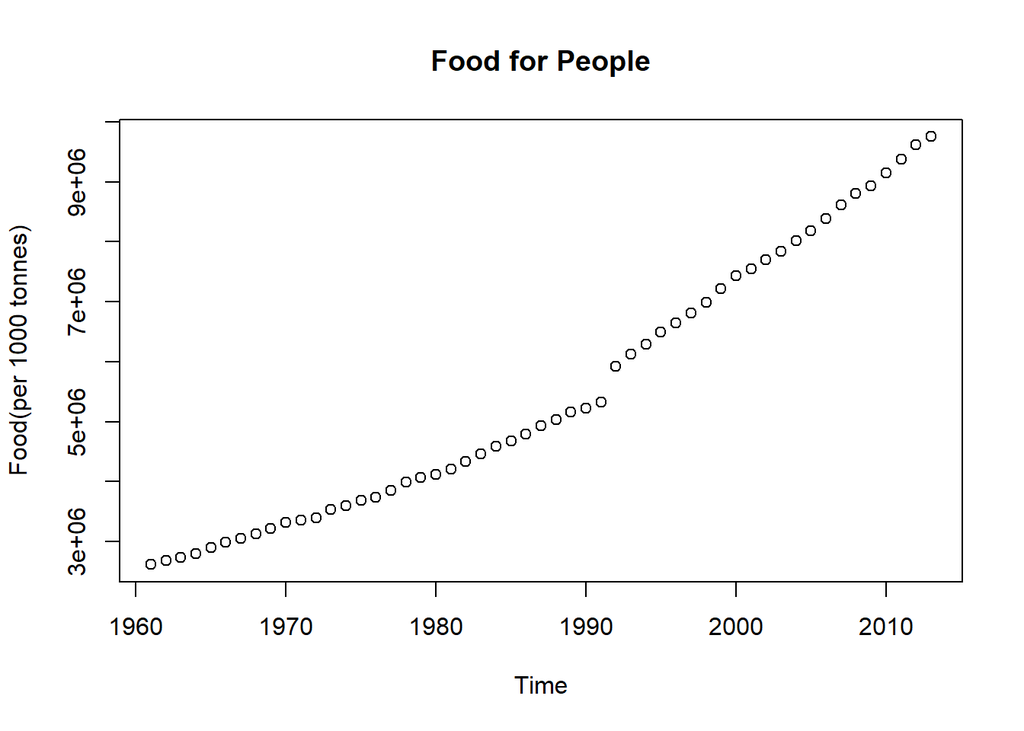

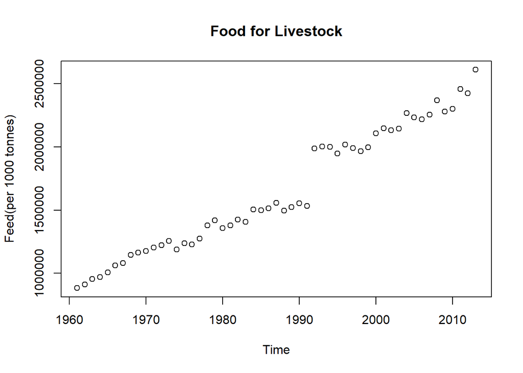

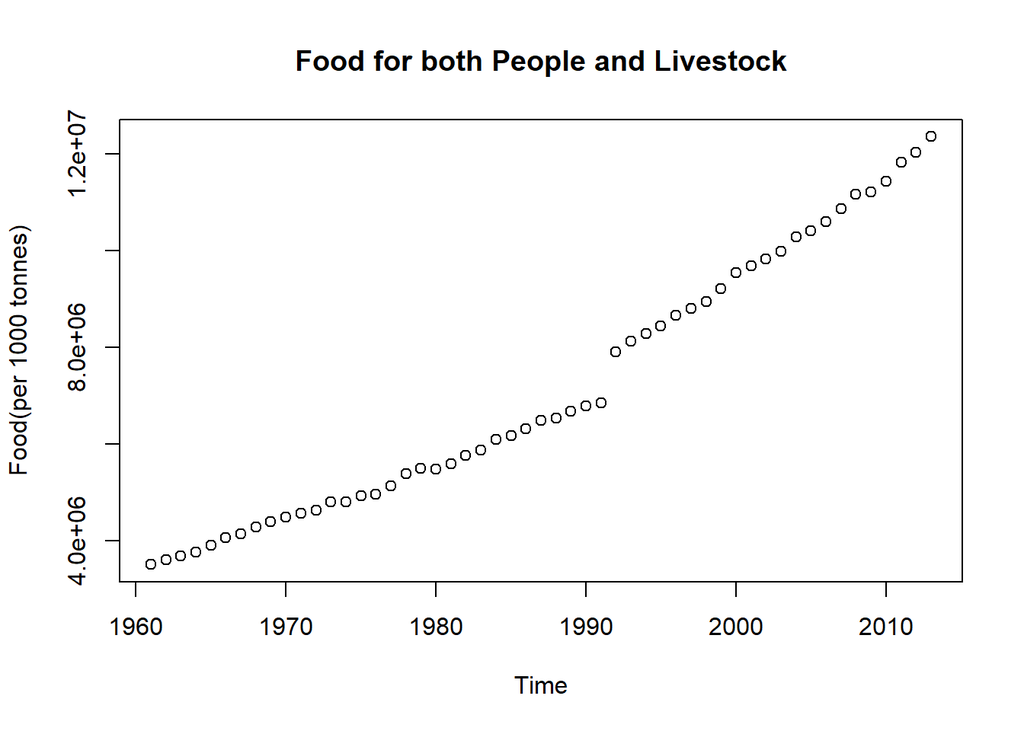

The research I found depicting food production was also discussing the consequences of growing population. In the Kaggle explanation, it talks about how agriculture is a huge topic because of the ever growing problem with climate change and population growing. How we grow the food we plan to eat will impact how many people get fed. The set contains extensive data, with well over 250,000 data points, and spans about 10 features, besides time. The data contains what is produced by a little over 200 countries and specifies what is produced and the amount (in tonnes). Each food item is categorized by a specific **Item.code** along with the actual name of the **Item**. The product is also categorized as Food or Feed, which is where my data manipulation comes in, as I broke the column up into two separate columns: a unit column of 1’s, denoted U, and a food column, if the **Element** was Food then the value was given a 1, if Feed then the value was given a 0. These two columns allowed for me to take just the raw data, from 1961-2013, and dot the Food column and U column to get the sum of all the Food produced in the year. The method I used can be looked through and I did all the programming so it’s not as clean as a 1-line `dot()`, but I managed by picking apart the data and using the `colSum()` method to get the sums and this omitted *NA* values. There were huge chunks of missing data, but this is the most complete agricultural set for as many countries as I could find. The units are “per 1,000 tonnes”

### Analysis

From the data we can see right away that livestock has much more variable data and also is fed so much less. This could be the cause of the variability in the graph, because in comparison to the graph plotting food for people, we see much more stable activity. All the graphs are very linear, and the graph plotting food for both people and livestock could be considered exponential and we will run some models on it and see what looks best.

We have no way of knowing the actual relationship between people food and livestock food, so I will separate the data and only do my calculations on this subset of the complete dataset. Hopefully this doesn’t effect too much.

## Modeling

```r
y <- unlist(list_of_dataFrames[5])
x <- unlist(list_of_dataFrames[4])
x1 <- unlist(list_of_dataFrames[3])
x2 <- unlist(list_of_dataFrames[2])
x3 <- unlist(list_of_dataFrames[1])

pop_grow_model <- lm(x ~ time)
life_exp_model <- lm(x1 ~ time)
drt_model <- lm(x2 ~ time)
brt_model <- lm(x3 ~ time)
when <- c(2019,2021,2022,2023,2024,2026,2027,2028,2029,2031,2032,2033,2034,2036,2037,2038,2039,2041,2042,2043,2044,2046,2047,2048,2049)
temp_y <- y[0:59]
temp_x <- x[0:59]
temp_x1 <- x1[0:59]
temp_x2 <- x2[0:59]
temp_x3 <- x3[0:59]

pgm_pred <- get_predictions(when, pop_grow_model)
lem_pred <- get_predictions(when, life_exp_model)
drtm_pred <- get_predictions(when, drt_model)
brtm_pred <- get_predictions(when, brt_model)

added = temp_x+temp_x1+temp_x2+temp_x3-1
population_fit <- lm(log(temp_y) ~ added)
summary(population_fit)
```

```
##
## Call:
## lm(formula = log(temp_y) ~ added)
##
## Residuals:
##      Min       1Q   Median       3Q      Max
## -0.63137 -0.07215  0.00132  0.08655  0.19231
##
## Coefficients:
##              Estimate Std. Error t value Pr(>|t|)
## (Intercept) 33.370291   0.782897   42.62   <2e-16 ***
## added       -0.109519   0.007782  -14.07   <2e-16 ***
## ---
## Signif. codes:  0 '***' 0.001 '**' 0.01 '*' 0.05 '.' 0.1 ' ' 1
##
## Residual standard error: 0.1304 on 57 degrees of freedom
## Multiple R-squared:  0.7765, Adjusted R-squared:  0.7726
## F-statistic: 198.1 on 1 and 57 DF,  p-value: < 2.2e-16
```

```r
confint(population_fit)
```

```
##                 2.5 %     97.5 %
## (Intercept) 31.802568 34.9380146
## added       -0.125102 -0.0939352
```

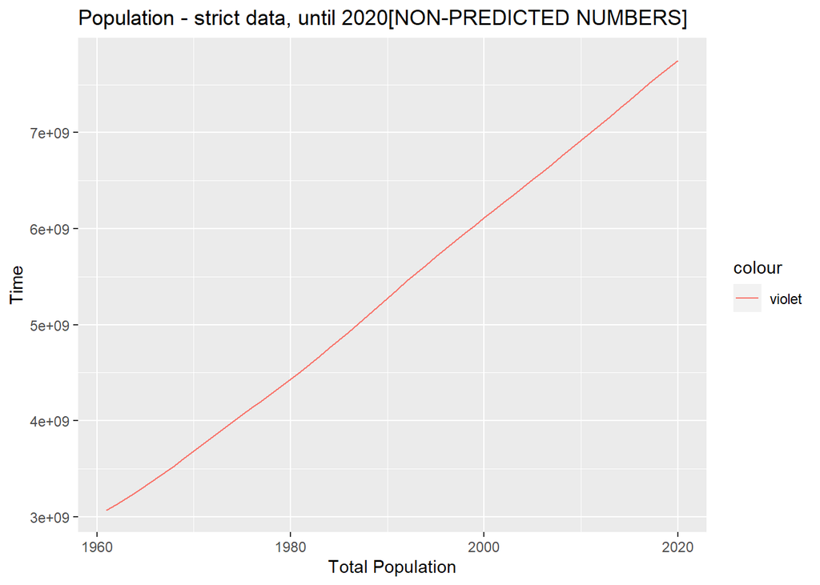

```r
qplot(time[0:59], temp_y, geom='line', main='Population - strict data, until 2020[NON-PREDICTED NUMBERS]', xlab='Total Population', ylab='Time', col='violet')
```

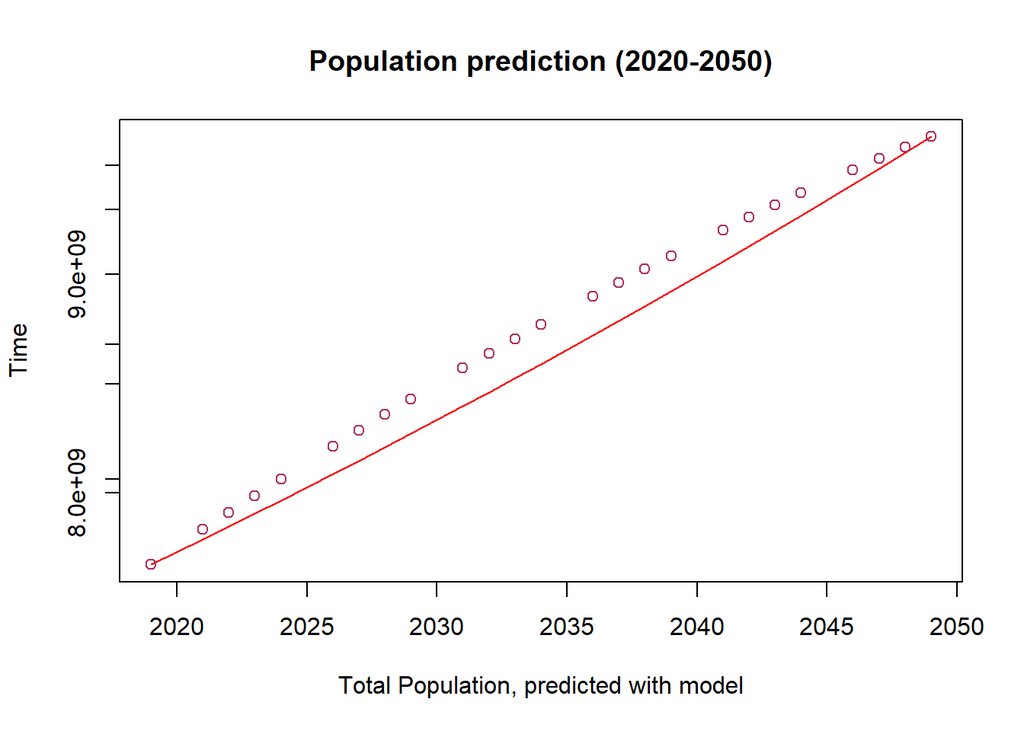

```r
added_pred <- pgm_pred + lem_pred + drtm_pred + brtm_pred
newTime = data.frame(added = added_pred)
pop_pred <- predict(population_fit, newdata=newTime)

get_y <- get_world_data(totpop,6)
wanted_y <- get_y[c(60,62,63,64,65,67,68,69,70,72,73,74,75,77,78,79,80,82,83,84,85,87,88,89,90)]

plot(x=unlist(when), y=exp(pop_pred), type='l', main='Population prediction (2020-2050)', col='red', xlab = '', ylab='',col.axis='white');par(new=TRUE)
plot(x=unlist(when), y=unlist(wanted_y), type='p', xlab='Total Population, predicted with model', ylab='Time', col='maroon')
```

```r
# reset y
y <- unlist(list_of_dataFrames[5])
```

Above we see that, when modeled, if we wanted to predict longer into the future we would see an “exponential looking” increase in population, which makes sense because we have no extra predictor feature that tells our model that earth has a carrying capacity or any kind of restriction with food.

```r
# Redefine variables
food <- get_food_sum(foodData, 0)
feed <- get_food_sum(foodData, 1)
both <- get_food_sum(foodData, 2)
food_drop <- c(1,2,3,4,5,6,7,8,9,10)
food_time <- get_all_time(foodData, food_drop)

lm_food_fit <- lm(food ~ food_time)
summary(lm_food_fit)
```

```
##
## Call:
## lm(formula = food ~ food_time)
##
## Residuals:
##     Min      1Q  Median      3Q     Max
## -734425 -273522    -739  319764  756265
##
## Coefficients:
##               Estimate Std. Error t value Pr(>|t|)
## (Intercept) -272347364    7219601  -37.72   <2e-16 ***
## food_time       139831       3633   38.49   <2e-16 ***
## ---
## Signif. codes:  0 '***' 0.001 '**' 0.01 '*' 0.05 '.' 0.1 ' ' 1
##
## Residual standard error: 404600 on 51 degrees of freedom
## Multiple R-squared:  0.9667, Adjusted R-squared:  0.9661
## F-statistic:  1481 on 1 and 51 DF,  p-value: < 2.2e-16
```

```r
confint(lm_food_fit)
```

```
##                    2.5 %       97.5 %
## (Intercept) -286841317.5 -257853409.8
## food_time       132537.2     147125.6
```

```r
log_food_fit <- lm(log(food) ~ food_time)
summary(log_food_fit)
```

```
##
## Call:
## lm(formula = log(food) ~ food_time)
##
## Residuals:
##       Min        1Q    Median        3Q       Max
## -0.057588 -0.019924  0.005005  0.018325  0.041673
##
## Coefficients:
##               Estimate Std. Error t value Pr(>|t|)
## (Intercept) -3.658e+01  4.418e-01  -82.78   <2e-16 ***
## food_time    2.618e-02  2.223e-04  117.73   <2e-16 ***
## ---
## Signif. codes:  0 '***' 0.001 '**' 0.01 '*' 0.05 '.' 0.1 ' ' 1
##
## Residual standard error: 0.02476 on 51 degrees of freedom
## Multiple R-squared:  0.9963, Adjusted R-squared:  0.9963
## F-statistic: 1.386e+04 on 1 and 51 DF,  p-value: < 2.2e-16
```

```r
confint(log_food_fit)
```

```
##                    2.5 %      97.5 %
## (Intercept) -37.46236657 -35.6883861
## food_time     0.02573163   0.0266244
```

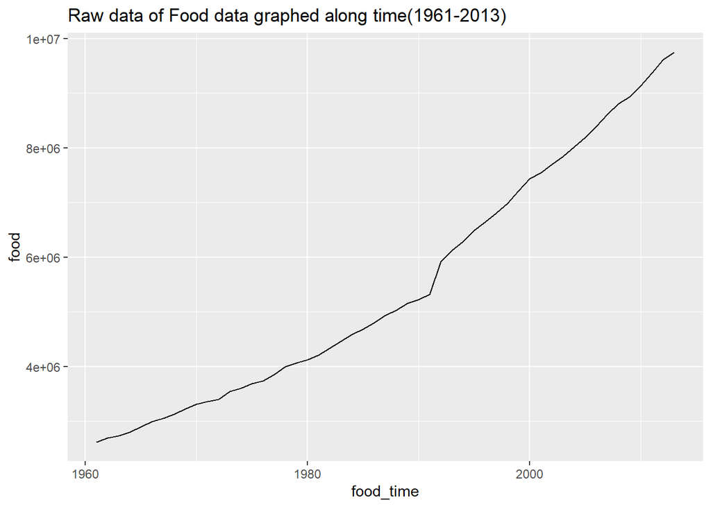

```r
qplot(food_time, food, geom='line', main='Raw data of Food data graphed along time(1961-2013)')
```

[figure not shown]

```r
newTime = data.frame(food_time = c(2014,2015,2016,2017,2018,2019,2020,2025,2030,2035,2040,2045,2050,2055,2060,2065,2070,2075,2080,2085,2090,2095,2100))
lm_pred <- predict(lm_food_fit, newdata=newTime)
log_pred <- predict(log_food_fit, newdata=newTime)

## This will be important later
predicted_food <- data.frame(values=exp(log_pred), years=c(2014,2015,2016,2017,2018,2019,2020,2025,2030,2035,2040,2045,2050,2055,2060,2065,2070,2075,2080,2085,2090,2095,2100))

qplot(unlist(newTime), lm_pred, geom='point', main='Linear Model fit - strict population data')
```

[figure not shown]

```r
qplot(unlist(newTime), exp(log_pred), geom='point', main='Linear Model fit - log of population data | values exponentiated for viewing')
```

The predictions made above have no idea that there are restrictions to agriculture and therefore they are standardized predictions. I believe the more interesting prediction will come when modeling population to food. This will show the food needed to keep the population going.

### Explained

When I moved on to the following graph I thought why predict the food data for a short amount of time (2014-2050) when I could predict it all the way through 2100. The food models are independent from population, their dependent on time. The year predicts the amount of food produced, and this is a pretty accurate model from the summary given. I was conflicted on what model to fit the data too, and that is why there are two separate models. A linear model and an exponential model that uses the log, then exponentiates the prediction to get the actual value.

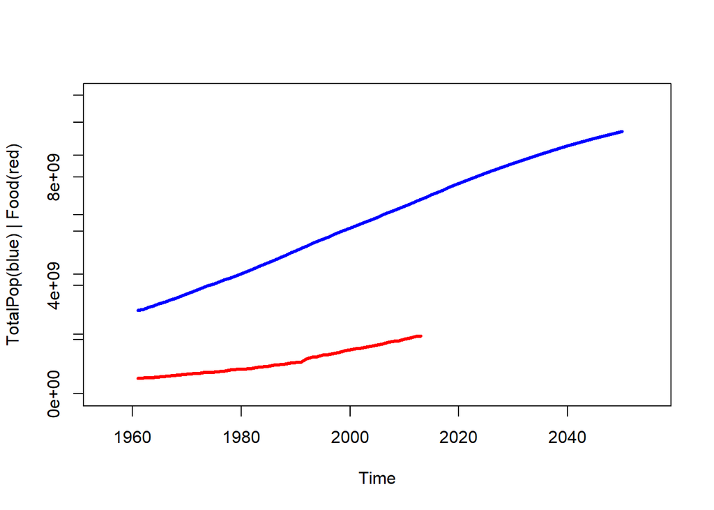

```r
plot(x=food_time,y=food, type="l", xlim = c(1955,2055), ylim = c(0, 50000000), lwd=3, col="Red", xlab='', ylab='',col.axis='white');par(new=TRUE)
plot(time,unlist(y), type="l", lwd=3, xlim = c(1955,2055), ylim = c(0, 11000000000), ylab="TotalPop(blue) | Food(red)", xlab="Time", col='blue')
```

Y-axis limits are different,

just to show comparison. The actual size of population compared to food is:

[output not shown]

So for every 1,000 tonnes of food, we can feed about 750 people, this would be as of 2010. This is interesting because it’s a completely independent calculation from time. If one was quick to assume the statistic, one might say that 0.750 people per ton, being independent from time, is standard for any year. Therefore further analysis isn’t actually needed, because from this calculation we can say that if the population got to be 10 billion then we’d need roughly over 13 billion tonnes of food to feed these 10 billion people. This will be an interesting statistic if the models align with this hypothesis. If this is a correct assumption, then we’d be dealing with a linear correlation between population and food, which makes sense.

This is not a correct assumption, though I thought it was while writing up the paper, and I came to realize by the end of the paper.

Let’s see if we can model the two together.

```r
foodTime <- data.frame(food_time = c(2014:2050))
predFood <- predict(log_food_fit, newdata=foodTime)
newf <- list(unlist(food), exp(predFood))

newy <- list(temp_y[1:58], wanted_y[1], temp_y[59], wanted_y[2:5], y[60], wanted_y[6:9], y[61], wanted_y[10:13], y[62], wanted_y[14:17], y[63], wanted_y[18:21], y[64], wanted_y[22:25], y[65])

df <- data.frame(pop=unlist(newy), new=unlist(newf))
fit <- lm(log(new) ~ pop, data=df)
summary(fit)
```

```
##
## Call:
## lm(formula = log(new) ~ pop, data = df)
##
## Residuals:
##      Min       1Q   Median       3Q      Max
## -0.05743 -0.02968  0.00029  0.02106  0.10143
##
## Coefficients:
##              Estimate Std. Error t value Pr(>|t|)
## (Intercept) 1.375e+01  1.168e-02  1176.9   <2e-16 ***
## pop         3.350e-10  1.715e-12   195.3   <2e-16 ***
## ---
## Signif. codes:  0 '***' 0.001 '**' 0.01 '*' 0.05 '.' 0.1 ' ' 1
##
## Residual standard error: 0.033 on 88 degrees of freedom
## Multiple R-squared:  0.9977, Adjusted R-squared:  0.9977
## F-statistic: 3.815e+04 on 1 and 88 DF,  p-value: < 2.2e-16
```

```r
confint(fit)
```

```
##                    2.5 %       97.5 %
## (Intercept) 1.372352e+01 1.376994e+01
## pop         3.315664e-10 3.383825e-10
```

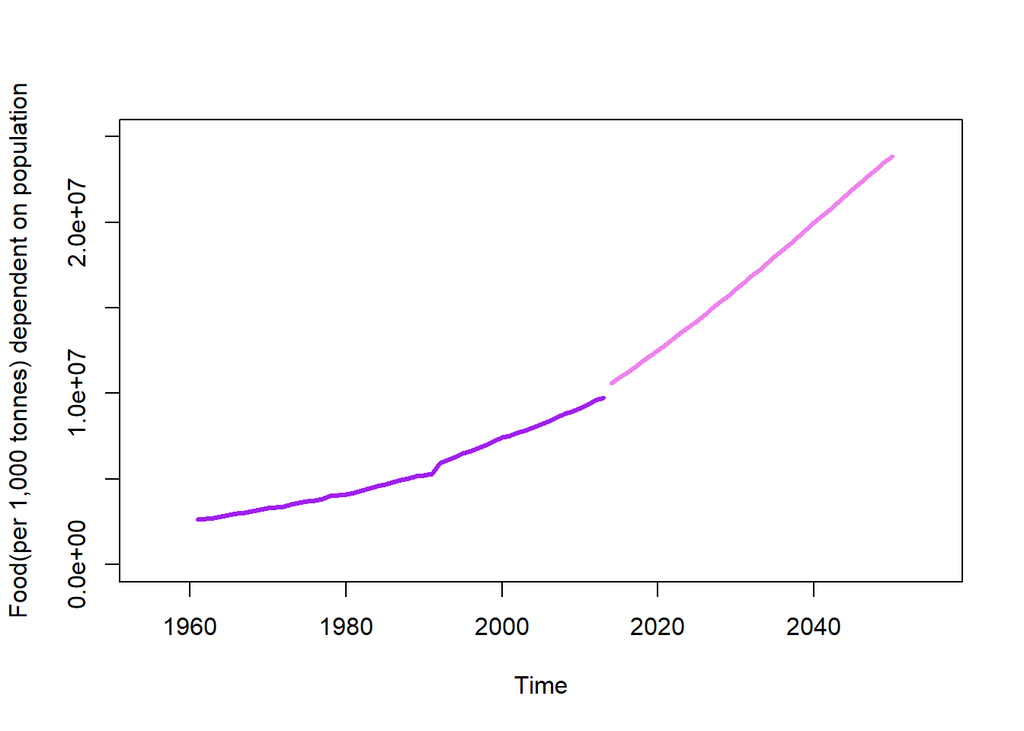

```r
#cor(unlist(newf), unlist(newy))

check <- unlist(newy)
predPop = data.frame(pop=check[54:90])
prediction <- predict(fit, newdata=predPop)

new_predicted_food <- data.frame(values=exp(prediction), years=c(2014,2015,2016,2017,2018,2019,2020,2021,2022,2023,2024,2025,2026,2027,2028,2029,2030,2031,2032,2033,2034,2035,2036,2037,2038,2039,2040,2041,2042,2043,2044,2045,2046,2047,2048,2049,2050))

plot(x=food_time,y=food, type="l", xlim = c(1955,2055), ylim = c(0, 25000000), lwd=3, col="Purple", xlab='', ylab='',col.axis='white');par(new=TRUE)
plot(x=c(2014,2015,2016,2017,2018,2019,2020,2021,2022,2023,2024,2025,2026,2027,2028,2029,2030,2031,2032,2033,2034,2035,2036,2037,2038,2039,2040,2041,2042,2043,2044,2045,2046,2047,2048,2049,2050), y=exp(prediction), type="l", lwd=3, xlim = c(1955,2055), ylim = c(0, 25000000), ylab="Food(per 1,000 tonnes) dependent on population", xlab="Time", col='violet')
```

The following is the confidence interval and the predictions for Food(in tonnes) dependent on population when ran against a linear model.

[output not shown]

```r
cor(unlist(newf), unlist(newy))
```

```
## [1] 0.9473674
```

Also, above, I got the correlation between the food data(1961-2050), raw data with predicted food data appended(2014-2050), correlated with the original population data(1960-2050). The correlation is strong, which is what I deducted above when analyzing the graphs. The model made above was not a linear model, meaning the correlation between the two statistics is not linear. I tried through trial and error and found it wasn’t worth putting the work into the RMD file, except for the above info. I then went to an exponential model and saw that it fit the data well and made sense with the actual predictions.

#### Analytical Explanation

To explain the data, the population data was already determined to look like some exponential-like data. This was also that case with the food production data, except if I had a more extensive knowledge of R I’d be able to try other models and see what fits better. This analysis, using the exponential model to fit the data works well enough, even with some of the population and food production data already being predicted.

#### Actual Explanation

A legitimate explanation could be that with an increase in food, one could say there’s an increase in discarded food that’s not actually consumed and therefore should be considered “noise” in the food production data due to the fact that not every bit of food is being used to feed people. This is also a huge problem, that will not be discussed in this paper. Other reasons may include:

- as the world has evolved into a more connected community world-wide, we have a fast amount of food that is available to the masses that wasn’t years ago
- the wealthier people get the more they can spend on food
- obesity has sky-rocketed (speaking of the last 30-40 years) since the early part of the 20th century

```r
# 'Predicted Food productions per 1,000 tonnes for 2020-2050 based on Total Population'
print(new_predicted_food)
```

```
##         values years
## X2014 10603708  2014
## X2015 10909002  2015
## X2016 11225270  2016
## X2017 11548641  2017
## X2018 11873703  2018
## X2019 12202739  2019
## X2020 12533614  2020
## X2021 12870641  2021
## X2022 13212618  2022
## X2023 13559284  2023
## X2024 13910400  2024
## X2025 14266072  2025
## X2026 14625884  2026
## X2027 14989693  2027
## X2028 15357274  2028
## X2029 15728382  2029
## X2030 16102842  2030
## X2031 16480409  2031
## X2032 16860756  2032
## X2033 17243474  2033
## X2034 17628400  2034
## X2035 18015461  2035
## X2036 18404435  2036
## X2037 18795396  2037
## X2038 19187964  2038
## X2039 19581863  2039
## X2040 19976693  2040
## X2041 20372004  2041
## X2042 20767427  2042
## X2043 21162401  2043
## X2044 21556336  2044
## X2045 21948764  2045
## X2046 22339040  2046
## X2047 22727012  2047
## X2048 23112167  2048
## X2049 23494127  2049
## X2050 23869748  2050
```

```r
# 'Predicted Food productions per 1,000 tonnes for 2020-2050 based on Time',
print(predicted_food)
```

```
##      values years
## 1  10294752  2014
## 2  10567807  2015
## 3  10848104  2016
## 4  11135835  2017
## 5  11431198  2018
## 6  11734396  2019
## 7  12045635  2020
## 8  13730126  2025
## 9  15650181  2030
## 10 17838741  2035
## 11 20333355  2040
## 12 23176821  2045
## 13 26417925  2050
## 14 30112273  2055
## 15 34323248  2060
## 16 39123096  2065
## 17 44594167  2070
## 18 50830325  2075
## 19 57938564  2080
## 20 66040836  2085
## 21 75276150  2090
## 22 85802953  2095
## 23 97801850  2100
```

### Answering the Question

Yes! We can feed 10 billion people, we would just need to be careful with how food is allocated.

- sustainable intensification – producing more from the same amount of land with fewer and less profound negative effects on the environment.
- increasing the use of nitrogen fertilizer
- feeding people equitably
- the effect of capitalism on the farmers of the world
- inflation of natural resources(such as food, water, non-renewable resources)

$\blacksquare$

## Problems With This Paper

The project is a sound piece of work, with a handful of exceptions that I will clarify here. Mr. Diaz, I’ll make this a quick bit of the project but I wrote it in because I am a good programmer, but R has it’s quirks and sandbox (even sandbox-like) problems are no real challenge compared to an actual real-world problem like this so I hope that you are kind with grading. I also had the last couple of days to do this project because of the car data being to simple, so I hope you understand the lacking work that could have been in the project.

- `nls()` modeling, I didn’t have a strong (enough) understanding of `nls()` and how it’s tied to exponential modeling to use it, so I stuck to the simplistic version, where you take the log of the data and convert the prediction back by exponentiation.
- I could have extended the modeling part of the paper by looking at the predictions of population from 2050-2100 and then using that predicted population data to predict even more Food production data. **PROBLEM** : This may have been a good idea, but I amateurly modeled the population data, which would have just led to a more systematic, and exponential, increase in population and the Food production for the predicted years would have followed suite, so I decided not to include, a likely flawed, prediction.
- Possible typo’s.
- I did not discuss any of the population data, except to discuss in a broad view of the data and I didn’t explore any of the other data. An interesting part of the project could have been to talk about the Death Rate and try to re-create the predicted values that came with the data.
- The units for the food production data is “per 1,000 tonnes”, which I had been writing as “per ton” in a couple of contexts. I tried to double check my work, but I don’t have fresh eyes.

## References

The World Bank : [Population Data](https://datacatalog.worldbank.org/dataset/population-estimates-and-projections) - Only used the main population data - Disregarded all other CSV files

Kaggle : [Food Data](https://www.kaggle.com/dorbicycle/world-foodfeed-production)